# Advanced Machine Learning - EasyVisa

### Observations :

**Test recall is very high (87%)** excellent for this problem.

**Train Recall (88%) and Test Recall (87%)** are almost identical

The model generalizes extremely well.

The model performs very well for visa approval prediction, with a high and stable recall of ~87% on both train and test data. This means the model successfully minimizes false negatives and is reliable for identifying true Certified cases — exactly what is needed for this problem.

**AdaBoost Classifier**

```
================ TRAINING PERFORMANCE ================
              precision    recall  f1-score   support

           0       0.66      0.39      0.49      5912
           1       0.75      0.90      0.82     11900

    accuracy                           0.73     17812
   macro avg       0.71      0.65      0.66     17812
weighted avg       0.72      0.73      0.71     17812

Train Accuracy: 0.7316977318661576
Train Precision: 0.7488989863684027
Train Recall: 0.9002521008403361
Train F1 Score: 0.8176302232398397

================ TEST PERFORMANCE ================
              precision    recall  f1-score   support

           0       0.68      0.42      0.52      2534
           1       0.76      0.90      0.82      5101

    accuracy                           0.74      7635
   macro avg       0.72      0.66      0.67      7635
weighted avg       0.73      0.74      0.72      7635

Test Accuracy: 0.7410609037328094
Test Precision: 0.7566546171541242
Test Recall: 0.9027641638894335
Test F1 Score: 0.8232770179672835

Confusion Matrix - TRAIN DATA
```

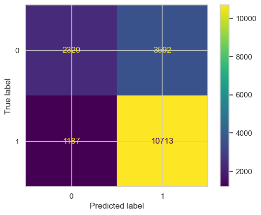

```
Confusion Matrix - TEST DATA
```

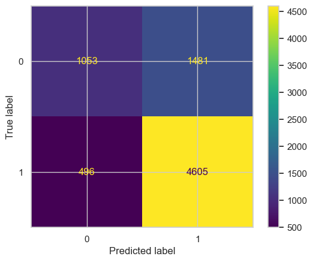

```python
train_and_evaluate_model(AdaBoostClassifier())
```

### Observations :

**Test Recall is very high (90%) — Excellent performance**

**Train Recall (90%) ≈ Test Recall (90%)**

The model generalizes extremely well.

No signs of overfitting or underfitting in terms of recall.

The model is highly effective for visa approval prediction, achieving an excellent 90% recall on both train and test sets. This means it consistently and reliably identifies true Certified applicants, making it well-optimized for the business goal where recall is the most important metric.

**XGB Classifier**

```
================ TRAINING PERFORMANCE ================
              precision    recall  f1-score   support

           0       0.82      0.65      0.73      5912
           1       0.84      0.93      0.88     11900

    accuracy                           0.84     17812
   macro avg       0.83      0.79      0.80     17812
weighted avg       0.84      0.84      0.83     17812

Train Accuracy: 0.8370761284527285
Train Precision: 0.8422854534388314
Train Recall: 0.9303361344537815
Train F1 Score: 0.8841239418623223

================ TEST PERFORMANCE ================
              precision    recall  f1-score   support

           0       0.63      0.50      0.55      2534
           1       0.77      0.85      0.81      5101

    accuracy                           0.74      7635
   macro avg       0.70      0.67      0.68      7635
weighted avg       0.73      0.74      0.73      7635

Test Accuracy: 0.7354289456450557
Test Precision: 0.7731867352367441
Test Recall: 0.8547343658106253
Test F1 Score: 0.8119180633147114

Confusion Matrix - TRAIN DATA
```

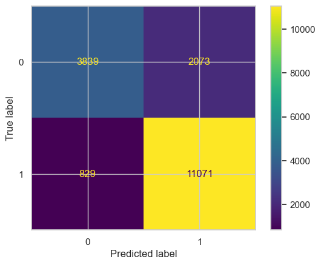

```
Confusion Matrix - TEST DATA
```

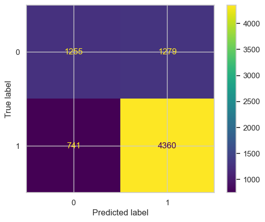

```python
train_and_evaluate_model(XGBClassifier())
```

### Observations :

**Test Recall is high (85%) — very good performance**

**Train Recall (93%) is higher than Test Recall (85%)**

The drop indicates mild overfitting, but the model still generalizes well on recall.

Model strongly prioritizes detecting Certified cases

- Class “1” (Certified) recall is 85%
- Class “0” (Denied) recall is only 50%

With 85% recall on test data, it captures the majority of true Certified visa applications, making it suitable for reducing false negatives and supporting visa approval decisions.

## Model Building - Oversampled Data

**Will use SMOTE, because it is the most effective and widely accepted oversampling method.**

```python
# Applying SMOTE on Training Data Only
from imblearn.over_sampling import SMOTE

smote = SMOTE(random_state=42)
X_train_sm, y_train_sm = smote.fit_resample(X_train, y_train)
```

```python
# Checking Class Balance After Oversampling
print("Before Oversampling:", y_train.value_counts())
print("After Oversampling:", y_train_sm.value_counts())
```

```
Before Oversampling: case_status
1    11900
0     5912
Name: count, dtype: int64
After Oversampling: case_status
1    11900
0    11900
Name: count, dtype: int64
```

```python
model_names = []
accuracy_scores = []
precision_scores = []
recall_scores = []
f1_scores = []

def Oversampled_train_and_evaluate_model(model):
    # Fit model
    model.fit(X_train_sm, y_train_sm)

    # Predictions
    y_pred_train = model.predict(X_train_sm)
    y_pred_test = model.predict(X_test)

    # Train scores
    train_acc = accuracy_score(y_train_sm, y_pred_train)
    train_precision = precision_score(y_train_sm, y_pred_train)
    train_recall = recall_score(y_train_sm, y_pred_train)
    train_f1 = f1_score(y_train_sm, y_pred_train)

    # Test scores
    test_acc = accuracy_score(y_test, y_pred_test)
    test_precision = precision_score(y_test, y_pred_test)
    test_recall = recall_score(y_test, y_pred_test)
    test_f1 = f1_score(y_test, y_pred_test)

    # Print Train Results
    print("\n================ TRAINING PERFORMANCE ================")
    print(classification_report(y_train_sm, y_pred_train))
    print("Train Accuracy:", train_acc)
    print("Train Precision:", train_precision)
    print("Train Recall:", train_recall)
    print("Train F1 Score:", train_f1)

    # Print Test Results
    print("\n================ TEST PERFORMANCE ================")
    print(classification_report(y_test, y_pred_test))
    print("Test Accuracy:", test_acc)
    print("Test Precision:", test_precision)
    print("Test Recall:", test_recall)
    print("Test F1 Score:", test_f1)

    # Confusion Matrix (Train)
    print("\nConfusion Matrix - TRAIN DATA")
    ConfusionMatrixDisplay.from_predictions(y_train_sm, y_pred_train)
    plt.show()

    # Confusion Matrix (Test)
    print("\nConfusion Matrix - TEST DATA")
    ConfusionMatrixDisplay.from_predictions(y_test, y_pred_test)
    plt.show()

    # Store test scores
    model_names.append(model)
    accuracy_scores.append(test_acc)
    precision_scores.append(test_precision)
    recall_scores.append(test_recall)
    f1_scores.append(test_f1)
```

**Decision Tree Classifier after Oversampling**

```
================ TRAINING PERFORMANCE ================
              precision    recall  f1-score   support

           0       1.00      1.00      1.00     11900
           1       1.00      1.00      1.00     11900

    accuracy                           1.00     23800
   macro avg       1.00      1.00      1.00     23800
weighted avg       1.00      1.00      1.00     23800

Train Accuracy: 1.0
Train Precision: 1.0
Train Recall: 1.0
Train F1 Score: 1.0

================ TEST PERFORMANCE ================
              precision    recall  f1-score   support

           0       0.46      0.53      0.50      2534
           1       0.75      0.69      0.72      5101

    accuracy                           0.64      7635
   macro avg       0.61      0.61      0.61      7635
weighted avg       0.65      0.64      0.65      7635

Test Accuracy: 0.6396856581532416
Test Precision: 0.7489406779661016
Test Recall: 0.6930013722799451
Test F1 Score: 0.7198859586600143

Confusion Matrix - TRAIN DATA
```

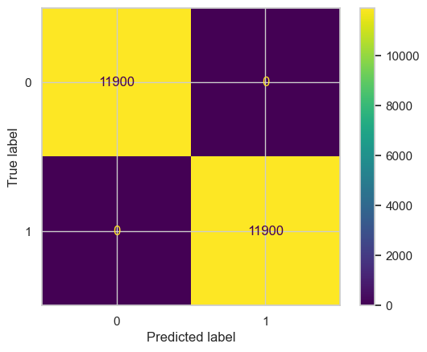

```
Confusion Matrix - TEST DATA
```

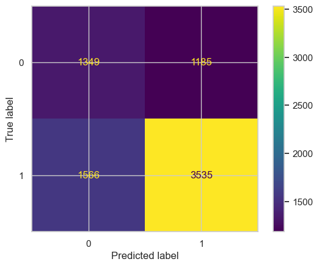

```python
Oversampled_train_and_evaluate_model(DecisionTreeClassifier())
```

### Observations :

**Extremely high overfitting after oversampling**

**Train Recall = 1.00, Test Recall = 0.69**

Accuracy dropped to 64%

Oversampling led to perfect training performance but poor generalization, with test recall only 69%, meaning the model still misses 1 out of 3 eligible visa approvals.

**Random Forest Classifier after Oversampling**

```
================ TRAINING PERFORMANCE ================
              precision    recall  f1-score   support

           0       1.00      1.00      1.00     11900
           1       1.00      1.00      1.00     11900

    accuracy                           1.00     23800
   macro avg       1.00      1.00      1.00     23800
weighted avg       1.00      1.00      1.00     23800

Train Accuracy: 1.0
Train Precision: 1.0
Train Recall: 1.0
Train F1 Score: 1.0

================ TEST PERFORMANCE ================
              precision    recall  f1-score   support

           0       0.55      0.61      0.58      2534
           1       0.80      0.75      0.77      5101

    accuracy                           0.71      7635
   macro avg       0.67      0.68      0.68      7635
weighted avg       0.71      0.71      0.71      7635

Test Accuracy: 0.7055664702030124
Test Precision: 0.7950361944157187
Test Recall: 0.7535777298568908
Test F1 Score: 0.7737520128824477

Confusion Matrix - TRAIN DATA
```

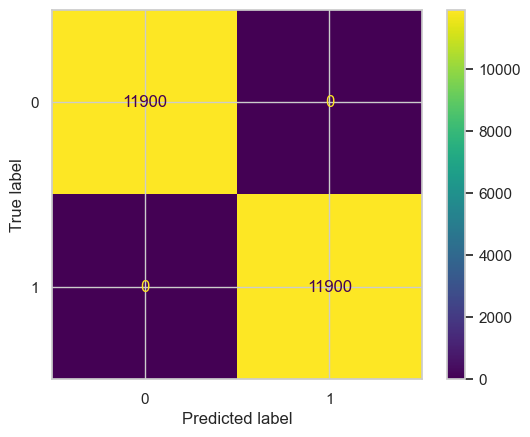

```
Confusion Matrix - TEST DATA
```

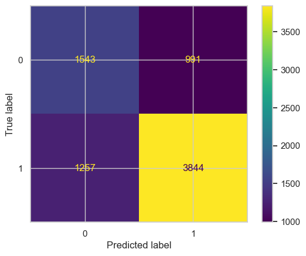

```python
Oversampled_train_and_evaluate_model(RandomForestClassifier())
```

### Observations :

**Test Recall is strong (76%) — a good improvement.**

**Severe overfitting in training results.**

- Train Recall = 1.00, Test Recall = 0.75

Precision is strong for Certified class (0.79).

**Bagging Classifier after Oversampling**

```
================ TRAINING PERFORMANCE ================
              precision    recall  f1-score   support

           0       0.97      0.99      0.98     11900
           1       0.99      0.97      0.98     11900

    accuracy                           0.98     23800
   macro avg       0.98      0.98      0.98     23800
weighted avg       0.98      0.98      0.98     23800

Train Accuracy: 0.9838235294117647
Train Precision: 0.9933167680575786
Train Recall: 0.9742016806722689
Train F1 Score: 0.9836663696915702

================ TEST PERFORMANCE ================
              precision    recall  f1-score   support

           0       0.51      0.64      0.57      2534
           1       0.79      0.69      0.74      5101

    accuracy                           0.67      7635
   macro avg       0.65      0.67      0.65      7635
weighted avg       0.70      0.67      0.68      7635

Test Accuracy: 0.6726915520628683
Test Precision: 0.7947439963751699
Test Recall: 0.6877082924916683
Test F1 Score: 0.7373620599054125

Confusion Matrix - TRAIN DATA
```

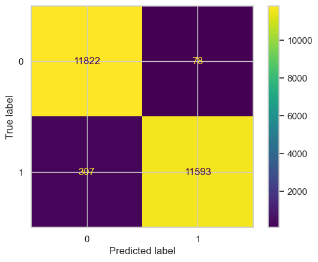

```
Confusion Matrix - TEST DATA
```

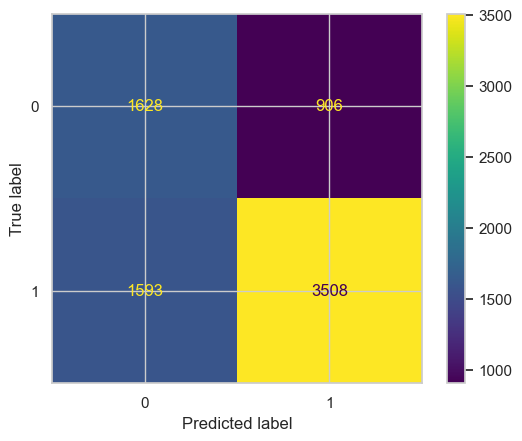

```python
Oversampled_train_and_evaluate_model(BaggingClassifier())
```

### Observations :

**Train Recall is extremely high (97%), but Test Recall drops to 69%.**

This large gap shows **overfitting** even after oversampling.

**Precision** for Certified cases is strong **(0.80)**, but Recall remains weak.

Oversampling created excellent training recall (97%) but resulted in moderate test recall (69%), indicating overfitting and insufficient recall improvement.

The model still misses nearly one-third of eligible visa applicants.

**Gradient Boosting Classifier after Oversampling**

```
================ TRAINING PERFORMANCE ================
              precision    recall  f1-score   support

           0       0.74      0.73      0.74     11900
           1       0.73      0.75      0.74     11900

    accuracy                           0.74     23800
   macro avg       0.74      0.74      0.74     23800
weighted avg       0.74      0.74      0.74     23800

Train Accuracy: 0.7389915966386554
Train Precision: 0.7339970380121771
Train Recall: 0.7496638655462184
Train F1 Score: 0.7417477342645714

================ TEST PERFORMANCE ================
              precision    recall  f1-score   support

           0       0.57      0.68      0.62      2534
           1       0.83      0.75      0.78      5101

    accuracy                           0.73      7635
   macro avg       0.70      0.72      0.70      7635
weighted avg       0.74      0.73      0.73      7635

Test Accuracy: 0.7253438113948919
Test Precision: 0.8262380538662033
Test Recall: 0.7457361301705548
Test F1 Score: 0.7839258114374034

Confusion Matrix - TRAIN DATA
```

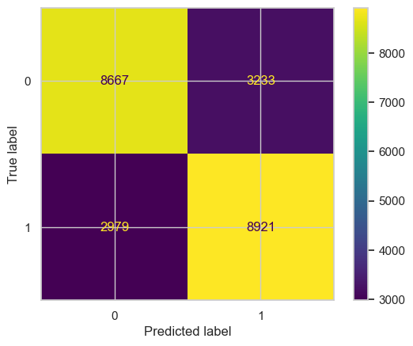

```
Confusion Matrix - TEST DATA
```

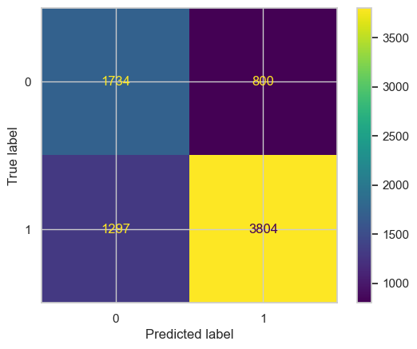

```python
Oversampled_train_and_evaluate_model(GradientBoostingClassifier())
```

### Observations :

**Test Recall improves and is reasonably good (75%).**

**Train Recall (75%) and Test Recall (75%) are almost identical**

The model correctly identifies 75% of Certified cases.

This is a successful improvement after oversampling and reduces false negatives.

Oversampling has produced a well-generalized model with strong Test Recall (75%), balanced class performance, and no overfitting.

However, we got better result for Recall score in Gradient Boosting Classifier without sampling.

**AdaBoost Classifier after Oversampling**

```
================ TRAINING PERFORMANCE ================
              precision    recall  f1-score   support

           0       0.71      0.67      0.69     11900
           1       0.69      0.72      0.70     11900

    accuracy                           0.70     23800
   macro avg       0.70      0.70      0.70     23800
weighted avg       0.70      0.70      0.70     23800

Train Accuracy: 0.6959663865546218
Train Precision: 0.6857871255576801
Train Recall: 0.7233613445378151
Train F1 Score: 0.7040732864387371

================ TEST PERFORMANCE ================
              precision    recall  f1-score   support

           0       0.55      0.67      0.60      2534
           1       0.82      0.73      0.77      5101

    accuracy                           0.71      7635
   macro avg       0.68      0.70      0.69      7635
weighted avg       0.73      0.71      0.72      7635

Test Accuracy: 0.7101506221349051
Test Precision: 0.8150087260034904
Test Recall: 0.7324054107037836
Test F1 Score: 0.7715023231801755

Confusion Matrix - TRAIN DATA
```

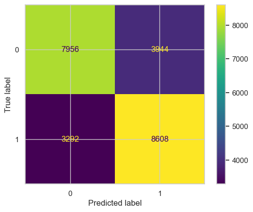

```
Confusion Matrix - TEST DATA
```

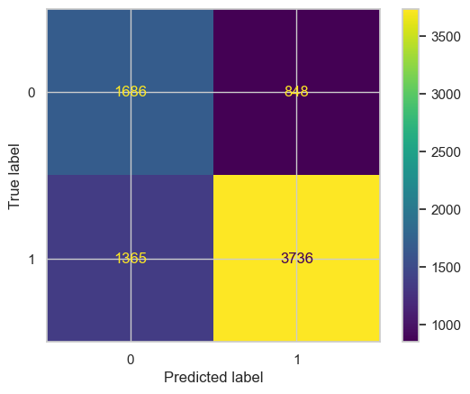

```python
Oversampled_train_and_evaluate_model(AdaBoostClassifier())
```

### Observation :

**Test Recall is good (73%) — strong improvement after oversampling.**

**Train Recall (72%) ≈ Test Recall (73%)**

Oversampling resulted in a well-balanced model with strong Test Recall (73%), minimal overfitting, and solid overall performance.

However, we got better result for Recall score in AdaBoost Classifier without sampling.

**XGB Classifier after Oversampling**

```
================ TRAINING PERFORMANCE ================
              precision    recall  f1-score   support

           0       0.87      0.83      0.85     11900
           1       0.84      0.88      0.86     11900

    accuracy                           0.85     23800
   macro avg       0.85      0.85      0.85     23800
weighted avg       0.85      0.85      0.85     23800

Train Accuracy: 0.8523529411764705
Train Precision: 0.8363548852879833
Train Recall: 0.8761344537815126
Train F1 Score: 0.8557826479520644

================ TEST PERFORMANCE ================
              precision    recall  f1-score   support

           0       0.60      0.58      0.59      2534
           1       0.79      0.80      0.80      5101

    accuracy                           0.73      7635
   macro avg       0.69      0.69      0.69      7635
weighted avg       0.73      0.73      0.73      7635

Test Accuracy: 0.7295350360183366
Test Precision: 0.7936170212765957
Test Recall: 0.8043520878259165
Test F1 Score: 0.7989484957647746

Confusion Matrix - TRAIN DATA
```

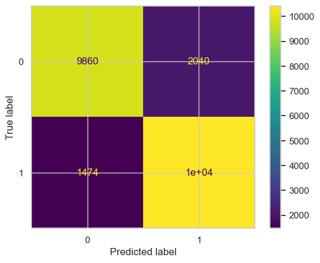

```
Confusion Matrix - TEST DATA
```

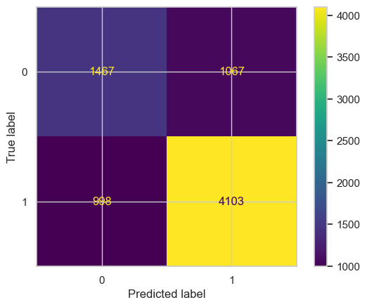

```python
Oversampled_train_and_evaluate_model(XGBClassifier())
```

### Observations :

**Test Recall is strong (80%) — a very good result.**

The model correctly identifies 80% of Certified cases, meaning far fewer false negatives.

Oversampling helped the model achieve a strong Test Recall of 80%, meaning it correctly identifies the majority of Certified applicants with good precision and balanced performance.

However, we got better result for Recall score in AdaBoost Classifier without sampling.

## Model Building - Undersampled Data

```python
# Applying Random under sampler on training data only.

from imblearn.under_sampling import RandomUnderSampler
rus = RandomUnderSampler(random_state=42)
X_train_under, y_train_under = rus.fit_resample(X_train, y_train)
```

```python
# Checking Class Balance After Oversampling
print("Before undersampling:", y_train.value_counts())
print("After undersampling:", y_train_under.value_counts())
```

```
Before undersampling: case_status
1    11900
0     5912
Name: count, dtype: int64
After undersampling: case_status
1    5912
0    5912
Name: count, dtype: int64
```

```python
model_names = []
accuracy_scores = []
precision_scores = []
recall_scores = []
f1_scores = []

def Undersampled_train_and_evaluate_model(model):
    # Fit model
    model.fit(X_train_under, y_train_under)

    # Predictions
    y_pred_train = model.predict(X_train_under)
    y_pred_test = model.predict(X_test)

    # Train scores
    train_acc = accuracy_score(y_train_under, y_pred_train)
    train_precision = precision_score(y_train_under, y_pred_train)
    train_recall = recall_score(y_train_under, y_pred_train)
    train_f1 = f1_score(y_train_under, y_pred_train)

    # Test scores
    test_acc = accuracy_score(y_test, y_pred_test)
    test_precision = precision_score(y_test, y_pred_test)
    test_recall = recall_score(y_test, y_pred_test)
    test_f1 = f1_score(y_test, y_pred_test)

    # Print Train Results
    print("\n================ TRAINING PERFORMANCE ================")
    print(classification_report(y_train_under, y_pred_train))
    print("Train Accuracy:", train_acc)
    print("Train Precision:", train_precision)
    print("Train Recall:", train_recall)
    print("Train F1 Score:", train_f1)

    # Print Test Results
    print("\n================ TEST PERFORMANCE ================")
    print(classification_report(y_test, y_pred_test))
    print("Test Accuracy:", test_acc)
    print("Test Precision:", test_precision)
    print("Test Recall:", test_recall)
    print("Test F1 Score:", test_f1)

    # Confusion Matrix (Train)
    print("\nConfusion Matrix - TRAIN DATA")
    ConfusionMatrixDisplay.from_predictions(y_train_under, y_pred_train)
    plt.show()

    # Confusion Matrix (Test)
    print("\nConfusion Matrix - TEST DATA")
    ConfusionMatrixDisplay.from_predictions(y_test, y_pred_test)
    plt.show()

    # Store test scores
    model_names.append(model)
    accuracy_scores.append(test_acc)
    precision_scores.append(test_precision)
    recall_scores.append(test_recall)
    f1_scores.append(test_f1)
```

**Decision Tree Classifier after undersampling**

```
================ TRAINING PERFORMANCE ================
              precision    recall  f1-score   support

           0       1.00      1.00      1.00      5912
           1       1.00      1.00      1.00      5912

    accuracy                           1.00     11824
   macro avg       1.00      1.00      1.00     11824
weighted avg       1.00      1.00      1.00     11824

Train Accuracy: 1.0
Train Precision: 1.0
Train Recall: 1.0
Train F1 Score: 1.0

================ TEST PERFORMANCE ================
              precision    recall  f1-score   support

           0       0.44      0.62      0.51      2534
           1       0.76      0.61      0.68      5101

    accuracy                           0.61      7635
   macro avg       0.60      0.61      0.60      7635
weighted avg       0.66      0.61      0.62      7635

Test Accuracy: 0.612573673870334
Test Precision: 0.7630739013012522
Test Recall: 0.6092922956283082
Test F1 Score: 0.6775670372792675

Confusion Matrix - TRAIN DATA
```

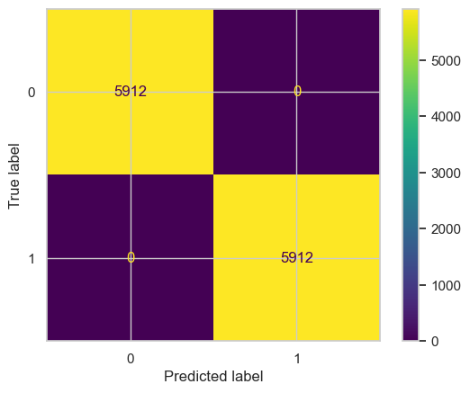

```
Confusion Matrix - TEST DATA
```

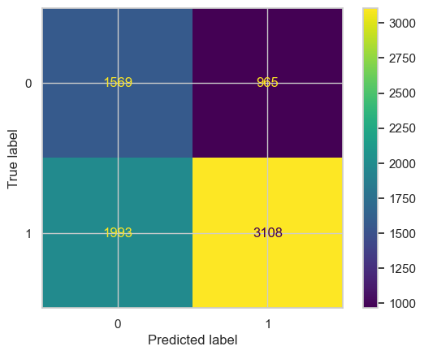

```python
Undersampled_train_and_evaluate_model(DecisionTreeClassifier())
```

**Random Forest Classifier after undersampling**

```
================ TRAINING PERFORMANCE ================
              precision    recall  f1-score   support

           0       1.00      1.00      1.00      5912
           1       1.00      1.00      1.00      5912

    accuracy                           1.00     11824
   macro avg       1.00      1.00      1.00     11824
weighted avg       1.00      1.00      1.00     11824

Train Accuracy: 0.9999154262516915
Train Precision: 1.0
Train Recall: 0.999830852503383
Train F1 Score: 0.9999154190983676

================ TEST PERFORMANCE ================
              precision    recall  f1-score   support

           0       0.52      0.71      0.60      2534
           1       0.82      0.68      0.74      5101

    accuracy                           0.69      7635
   macro avg       0.67      0.69      0.67      7635
weighted avg       0.72      0.69      0.70      7635

Test Accuracy: 0.6878847413228553
Test Precision: 0.8235714285714286
Test Recall: 0.6781023328759067
Test F1 Score: 0.7437909902161058

Confusion Matrix - TRAIN DATA
```

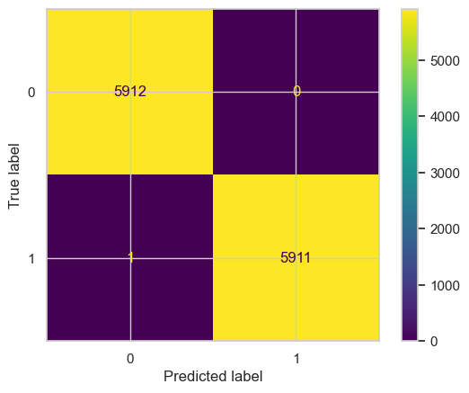

```
Confusion Matrix - TEST DATA
```

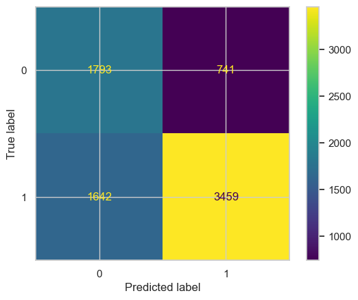

```python
Undersampled_train_and_evaluate_model(RandomForestClassifier())
```

**Bagging Classifier after Undersampling**

```
================ TRAINING PERFORMANCE ================
              precision    recall  f1-score   support

           0       0.97      0.99      0.98      5912
           1       0.99      0.97      0.98      5912

    accuracy                           0.98     11824
   macro avg       0.98      0.98      0.98     11824
weighted avg       0.98      0.98      0.98     11824

Train Accuracy: 0.9786874154262517
Train Precision: 0.9918317692040319
Train Recall: 0.9653247631935047
Train F1 Score: 0.9783987656437511

================ TEST PERFORMANCE ================
              precision    recall  f1-score   support

           0       0.48      0.72      0.57      2534
           1       0.81      0.61      0.70      5101

    accuracy                           0.64      7635
   macro avg       0.64      0.66      0.63      7635
weighted avg       0.70      0.64      0.65      7635

Test Accuracy: 0.6441388343156516
Test Precision: 0.8113897596656218
Test Recall: 0.6089002156439913
Test F1 Score: 0.6957106058909173

Confusion Matrix - TRAIN DATA
```

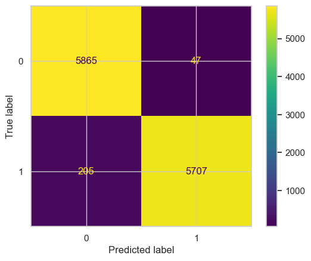

```
Confusion Matrix - TEST DATA
```

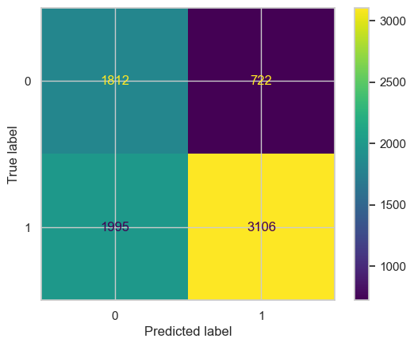

```python
Undersampled_train_and_evaluate_model(BaggingClassifier())
```

**Gradient Boosting Classifier after Undersampling**

```
================ TRAINING PERFORMANCE ================
              precision    recall  f1-score   support

           0       0.73      0.71      0.72      5912
           1       0.71      0.74      0.72      5912

    accuracy                           0.72     11824
   macro avg       0.72      0.72      0.72     11824
weighted avg       0.72      0.72      0.72     11824

Train Accuracy: 0.7209066305818674
Train Precision: 0.7145203679369251
Train Recall: 0.7357916102841678
Train F1 Score: 0.725

================ TEST PERFORMANCE ================
              precision    recall  f1-score   support

           0       0.56      0.71      0.62      2534
           1       0.83      0.72      0.77      5101

    accuracy                           0.72      7635
   macro avg       0.69      0.71      0.70      7635
weighted avg       0.74      0.72      0.72      7635

Test Accuracy: 0.7151277013752456
Test Precision: 0.8317460317460318
Test Recall: 0.7190746912370124
Test F1 Score: 0.7713174219324992

Confusion Matrix - TRAIN DATA
```

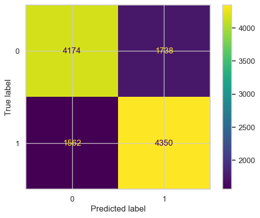

```
Confusion Matrix - TEST DATA
```

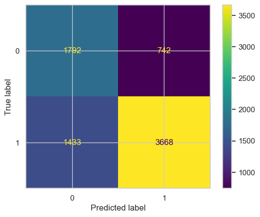

```python
Undersampled_train_and_evaluate_model(GradientBoostingClassifier())
```

**AdaBoost Classifier after Undersampling**

```
================ TRAINING PERFORMANCE ================
              precision    recall  f1-score   support

           0       0.72      0.61      0.66      5912
           1       0.66      0.76      0.71      5912

    accuracy                           0.69     11824
   macro avg       0.69      0.69      0.68     11824
weighted avg       0.69      0.69      0.68     11824

Train Accuracy: 0.6853856562922869
Train Precision: 0.6609397944199706
Train Recall: 0.7613328822733424
Train F1 Score: 0.7075931457318032

================ TEST PERFORMANCE ================
              precision    recall  f1-score   support

           0       0.57      0.62      0.59      2534
           1       0.80      0.76      0.78      5101

    accuracy                           0.72      7635
   macro avg       0.69      0.69      0.69      7635
weighted avg       0.73      0.72      0.72      7635

Test Accuracy: 0.7174852652259333
Test Precision: 0.8037556747833264
Test Recall: 0.7635757694569693
Test F1 Score: 0.7831506987031266

Confusion Matrix - TRAIN DATA
```

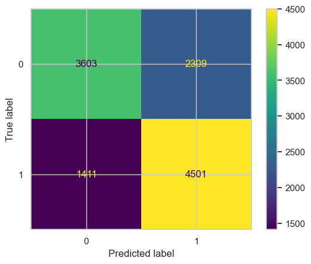

```
Confusion Matrix - TEST DATA
```

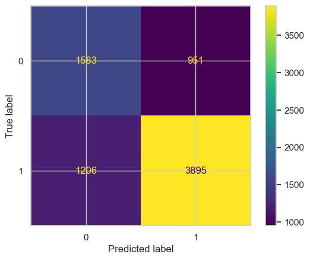

```python
Undersampled_train_and_evaluate_model(AdaBoostClassifier())
```

**XGB Classifier after Undersampling**

```
================ TRAINING PERFORMANCE ================
              precision    recall  f1-score   support

           0       0.86      0.84      0.85      5912
           1       0.85      0.86      0.85      5912

    accuracy                           0.85     11824
   macro avg       0.85      0.85      0.85     11824
weighted avg       0.85      0.85      0.85     11824

Train Accuracy: 0.8510656292286874
Train Precision: 0.845513567504578
Train Recall: 0.8591001353179973
Train F1 Score: 0.8522527057639063

================ TEST PERFORMANCE ================
              precision    recall  f1-score   support

           0       0.52      0.70      0.60      2534
           1       0.82      0.68      0.75      5101

    accuracy                           0.69      7635
   macro avg       0.67      0.69      0.67      7635
weighted avg       0.72      0.69      0.70      7635

Test Accuracy: 0.6895874263261297
Test Precision: 0.8212185368148671
Test Recall: 0.6843756126249755
Test F1 Score: 0.7465782720273738

Confusion Matrix - TRAIN DATA
```

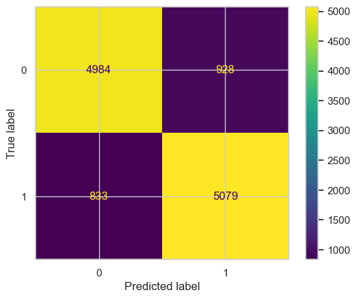

```
Confusion Matrix - TEST DATA
```

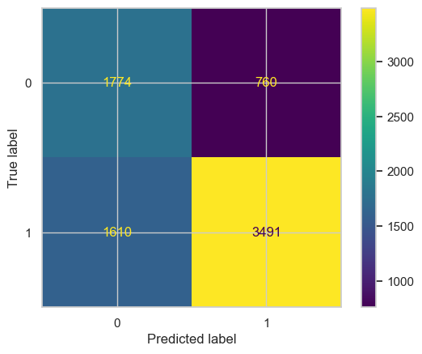

```python
Undersampled_train_and_evaluate_model(XGBClassifier())
```

### Overall observations after building model with undersampled technique.

**1 AdaBoost gives the BEST recall on test data.**

**AdaBoost Test Recall = 0.764** - Highest among all models

It correctly identifies 76% of Certified cases, making it the strongest recall-oriented model.

AdaBoost is the best model for recall after undersampling.

**2 Gradient Boosting is the second-best performer.**

**Gradient Boosting Test Recall = 0.719.**

Balanced performance without extreme overfitting.

A stable and reliable option if slightly less recall is acceptable.

**3 RandomForest and XGBoost give moderate recall.**

RF Recall = **0.679**

XGB Recall = **0.684**

Good precision, but recall is lower than boosting models.

**4 Decision Tree and Bagging perform the worst.**

They highly overfit the undersampled training data and perform poorly on test recall.

Undersampling reduced generalization capability.

Boosting models handle undersampling much better than bagging/tree models.

## Hyperparameter Tuning and Model Performances

**Following are 3 best performing models among all the models built previously with reason.**

- Very high recall with good stability.
- Good backup if AdaBoost overfits after heavy tuning.

**XGBoost (oversampled) — strong, robust (≈0.80 test)**

- High recall than AdaBoost/GB, but generally more stable and easier to regularize (fewest false negatives).
- Good candidates if need robustness and feature-importance interpretability.

```python
import time
from sklearn.metrics import make_scorer
from sklearn.model_selection import RandomizedSearchCV, StratifiedKFold
from scipy.stats import randint, uniform
```

```python
X_train_sm, y_train_sm
```

**Using RandomizedSearchCV for Hyperparameter Tuning**

```python
RND = 42
cv = StratifiedKFold(n_splits=5, shuffle=True, random_state=RND)
recall_scorer = make_scorer(recall_score, pos_label=1)

# ---------- AdaBoost ----------
ada = AdaBoostClassifier(random_state=RND)
ada_param_dist = {
        "estimator": [
        DecisionTreeClassifier(max_depth=d, min_samples_leaf=l, random_state=RND)
        for d in [1,2,3] for l in [1,2,4]
    ],
    "n_estimators": randint(50, 400),
    "learning_rate": uniform(0.01, 1.0)
}

# ---------- GradientBoosting (sklearn) ----------
gb = GradientBoostingClassifier(random_state=RND)
gb_param_dist = {
    "n_estimators": randint(100, 600),
    "learning_rate": uniform(0.01, 0.5),
    "max_depth": randint(2, 6),
    "min_samples_leaf": randint(1, 10),
    "subsample": uniform(0.6, 0.4)
}

# ---------- XGBoost ----------
xgb = XGBClassifier(use_label_encoder=False, eval_metric='logloss', random_state=RND)
xgb_param_dist = {
    "n_estimators": randint(100, 800),
    "learning_rate": uniform(0.01, 0.5),
    "max_depth": randint(3, 8),
    "subsample": uniform(0.6, 0.4),
    "colsample_bytree": uniform(0.5, 0.5),
    "gamma": uniform(0, 5),
    # optional imbalance handling
    "scale_pos_weight": [1, float(len(y_train_sm) - sum(y_train)) / (sum(y_train_sm) + 1e-6)]
}

# helper to run RandomizedSearchCV
def run_random_search(estimator, param_dist, n_iter=40, model_name="model"):
    rs = RandomizedSearchCV(
        estimator=estimator,
        param_distributions=param_dist,
        n_iter=n_iter,
        scoring=recall_scorer,
        cv=cv,
        verbose=1,
        n_jobs=-1,
        random_state=RND,
        return_train_score=False
    )
    t0 = time.time()
    rs.fit(X_train_sm, y_train_sm)
    t1 = time.time()
    print(f"\n{model_name} RandomizedSearchCV done in {(t1-t0):.1f}s  best CV recall={rs.best_score_:.4f}")
    print("best_params:", rs.best_params_)
    return rs

# Runing searches (choosing n_iter per model; smaller for AdaBoost because of many base_estimators)
rs_ada = run_random_search(ada, ada_param_dist, n_iter=30, model_name="AdaBoost")
rs_gb  = run_random_search(gb,  gb_param_dist,  n_iter=60, model_name="GradientBoosting")
rs_xgb = run_random_search(xgb, xgb_param_dist, n_iter=60, model_name="XGBoost")
```

```
Fitting 5 folds for each of 30 candidates, totalling 150 fits

AdaBoost RandomizedSearchCV done in 233.9s  best CV recall=0.7785
best_params: {'estimator': DecisionTreeClassifier(max_depth=1, random_state=42), 'learning_rate': np.float64(0.025636406741193933), 'n_estimators': 58}
Fitting 5 folds for each of 60 candidates, totalling 300 fits

GradientBoosting RandomizedSearchCV done in 1103.2s  best CV recall=0.8034
best_params: {'learning_rate': np.float64(0.10942120204440257), 'max_depth': 5, 'min_samples_leaf': 3, 'n_estimators': 518, 'subsample': np.float64(0.9085081386743783)}
Fitting 5 folds for each of 60 candidates, totalling 300 fits

XGBoost RandomizedSearchCV done in 943.5s  best CV recall=0.8113
best_params: {'colsample_bytree': np.float64(0.5451448850272042), 'gamma': np.float64(4.17651247794619), 'learning_rate': np.float64(0.17039003248586793), 'max_depth': 7, 'n_estimators': 759, 'scale_pos_weight': 0.9999999999159663, 'subsample': np.float64(0.871025744736913)}
```

**Using user-defined function coded for modeling building with over sampling**

**AdaBoost Classifier using Hyperparameter Tuning**

```
================ TRAINING PERFORMANCE ================
              precision    recall  f1-score   support

           0       0.68      0.47      0.55     11900
           1       0.59      0.78      0.67     11900

    accuracy                           0.62     23800
   macro avg       0.64      0.62      0.61     23800
weighted avg       0.64      0.62      0.61     23800

Train Accuracy: 0.623781512605042
Train Precision: 0.5943867743175701
Train Recall: 0.7794957983193277
Train F1 Score: 0.6744710245037446

================ TEST PERFORMANCE ================
              precision    recall  f1-score   support

           0       0.51      0.48      0.49      2534
           1       0.75      0.78      0.76      5101

    accuracy                           0.68      7635
   macro avg       0.63      0.63      0.63      7635
weighted avg       0.67      0.68      0.67      7635

Test Accuracy: 0.6763588736083824
Test Precision: 0.7489587277546383
Test Recall: 0.7755342089786317
Test F1 Score: 0.7620148319368198

Confusion Matrix - TRAIN DATA
```

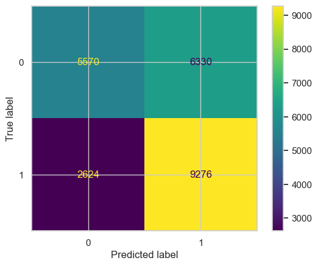

```
Confusion Matrix - TEST DATA
```

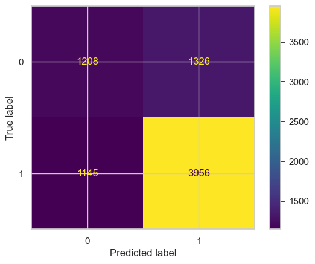

```python
Oversampled_train_and_evaluate_model(AdaBoostClassifier(estimator = DecisionTreeClassifier(max_depth=1, random_state=42),
              learning_rate = np.float64(0.025636406741193933), n_estimators = 58))
```

### Observations

**1 Recall is strong and consistent.**

**Test Recall = 0.775**, almost identical to **Train Recall = 0.779**.

This shows **good generalization** and **no overfitting**.

The model is effective at catching the **Certified (class 1)** cases, which is your priority.

**2 Model performs much better on class 1 than class 0.**

Class 1 recall: **0.78** (strong)

Class 0 recall: **0.48** (moderate)

Indicates the model still favors the positive class, which is expected with oversampling.

**3 Oversampling improved model balance.**

The model no longer collapses to predicting only one class.

Precision and recall for both classes are meaningful.

F1 score for class 1 is good **(0.76)**, supporting reliable predictions.

**4 Overall performance is reasonable.**

Test Accuracy = **0.68**

Test Precision = **0.75**

Test F1 Score = **0.76**

The model maintains a **good precision–recall tradeoff**.

**5 This is a usable recall-driven model.**

Stable performance across train and test.

Improved minority class detection due to oversampling.

Suitable for scenarios where **missing positive cases (Certified)** carries high risk.

**Gradient Boosting Classifier using Hyperparameter Tuning**

```
================ TRAINING PERFORMANCE ================
              precision    recall  f1-score   support

           0       0.89      0.86      0.88     11900
           1       0.86      0.90      0.88     11900

    accuracy                           0.88     23800
   macro avg       0.88      0.88      0.88     23800
weighted avg       0.88      0.88      0.88     23800

Train Accuracy: 0.8779411764705882
Train Precision: 0.8625554212011286
Train Recall: 0.8991596638655462
Train F1 Score: 0.8804772680518412

================ TEST PERFORMANCE ================
              precision    recall  f1-score   support

           0       0.61      0.58      0.59      2534
           1       0.79      0.81      0.80      5101

    accuracy                           0.73      7635
   macro avg       0.70      0.69      0.70      7635
weighted avg       0.73      0.73      0.73      7635

Test Accuracy: 0.7346430910281598
Test Precision: 0.7941457815190358
Test Recall: 0.8137620074495197
Test F1 Score: 0.8038342370255616

Confusion Matrix - TRAIN DATA
```

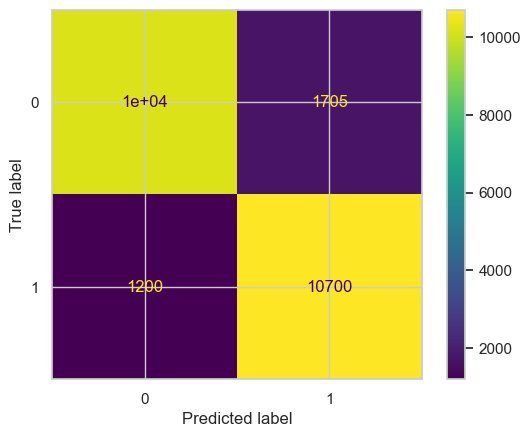

```
Confusion Matrix - TEST DATA
```

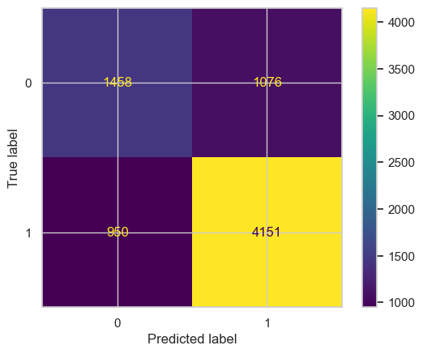

```python
Oversampled_train_and_evaluate_model(GradientBoostingClassifier(learning_rate = np.float64(0.10942120204440257), max_depth = 5, min_samples_leaf = 3,
           n_estimators = 518, subsample = np.float64(0.9085081386743783)))
```

### Observations :

**1 Recall is strong and consistent.**

**Test Recall = 0.814**, which is high and close to the **Train Recall = 0.899**.

The model is very effective at correctly identifying **Certified (class 1)** cases.

**2 Better recall and precision balance than AdaBoost.**

Precision (0.79) and Recall (0.81) are both strong.

This means the model is not only catching most positives but also maintaining good correctness.

**3 Model generalizes well.**

Train Accuracy = **0.88**, Test Accuracy = **0.73**

Though there's a performance drop from train to test, recall remains strong, indicating controlled overfitting.

**4 Class 1 performance is excellent.**

Class 1:

Precision: **0.79**

Recall: **0.81**

F1 Score: **0.80**

This is ideal when the goal is to avoid missing positive (Certified) cases.

**5 Class 0 performance is weaker but reasonable.**

Class 0 recall = **0.58** (moderate)

Shows the model focuses more on class 1 — expected due to oversampling and recall objective.

**6 Overall performance is stable and balanced.**

Macro test F1 = **0.70**

Indicates good balance between both classes despite class imbalance.

**XGB Classifier using Hyperparameter Tuning**

```
================ TRAINING PERFORMANCE ================
              precision    recall  f1-score   support

           0       0.88      0.82      0.84     11900
           1       0.83      0.88      0.85     11900

    accuracy                           0.85     23800
   macro avg       0.85      0.85      0.85     23800
weighted avg       0.85      0.85      0.85     23800

Train Accuracy: 0.8497899159663865
Train Precision: 0.8273177636234961
Train Recall: 0.8841176470588236
Train F1 Score: 0.8547751553804281

================ TEST PERFORMANCE ================
              precision    recall  f1-score   support

           0       0.62      0.57      0.59      2534
           1       0.79      0.83      0.81      5101

    accuracy                           0.74      7635
   macro avg       0.71      0.70      0.70      7635
weighted avg       0.74      0.74      0.74      7635

Test Accuracy: 0.7400130975769482
Test Precision: 0.7938513768389287
Test Recall: 0.825132326994707
Test F1 Score: 0.8091896568297606

Confusion Matrix - TRAIN DATA
```

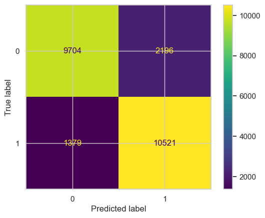

```
Confusion Matrix - TEST DATA
```

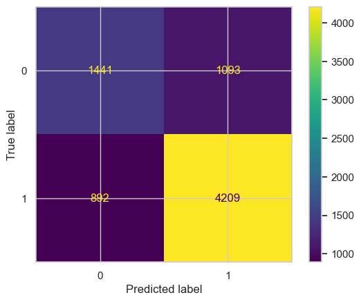

```python
Oversampled_train_and_evaluate_model(XGBClassifier(colsample_bytree= np.float64(0.5451448850272042),
gamma = np.float64(4.17651247794619), learning_rate = np.float64(0.17039003248586793),
max_depth = 7, n_estimators = 759, scale_pos_weight = 0.9999999999159663, subsample = np.float64(0.871025744736913)))
```

### Observations :

**1 High Recall on Test Data — Strong Positive Detection.**

**Test Recall = 0.825**

This shows the model is very good at identifying the majority class (Certified cases) — strong for recall-focused objectives.

**2 Good Precision–Recall Balance.**

Test Precision = **0.79**

Test Recall = **0.83**

F1 Score = **0.81**

This balance means the model not only detects most positives but also makes relatively accurate positive predictions.

**3 Generalization is stable.**

Train Recall = **0.884**

Test Recall = **0.825**

The drop is small - **good generalization** without severe overfitting.

**4 Better Class-1 performance (target class).**

Class 1:

Precision = **0.79**

Recall = **0.83**

F1 = **0.81**

This is ideal when you prioritize correctly classifying positive/approved cases.

**5 Moderate performance for minority class (Class 0).**

Class 0 recall = **0.57**

This is expected due to oversampling but still better than some other models.

**6 Accuracy and weighted scores confirm strong model.**

Test Accuracy = **0.74**

Weighted F1 = **0.74**

These confirm the model performs well overall across both classes.

## Performances of the tuned models.

| Model | Test Recall | Test Precision | Test F1 | Test Accuracy | Notes |
| --- | --- | --- | --- | --- | --- |
| **AdaBoost (Tuned)** | **0.776** | 0.749 | 0.762 | 0.676 | Moderate recall, weak minority class performance |
| **GradientBoosting (Tuned)** | **0.814** | 0.794 | 0.804 | 0.735 | High recall, strong balance, consistent |
| **XGBoost (Tuned)** | **0.825** | 0.794 | 0.809 | 0.740 | **Best recall**, strong stability, best F1 |

**1 AdaBoost (Tuned).**

Recall = **0.775** (lowest among the three)

Accuracy also lowest (0.67)

Struggles with detecting Class 0 (0.48 recall)

**Not suitable when recall is the priority**

**2 GradientBoosting (Tuned).**

Recall = **0.814**

Balanced precision (0.79) and F1 (0.80)

Very stable, no major overfitting

Performs better on minority class (class 0) than XGB

**A good and safe model** but XGBoost is still stronger in high-recall context.

**3 XGBoost (Tuned).**

- **Highest Recall = 0.825**
- Highest F1 = **0.809**
- Accuracy = **0.74**, also highest among the three
- Train–test gap small - good generalization
- Superior at finding positive cases (main target)

**This is the strongest model overall for recall-based evaluation.**

## FINAL MODEL SELECTION: XGBoost (Tuned).

**Why XGBoost Is the Best Final Model:**

The goal is **maximizing recall (minimizing false negatives), XGBoost is the optimal final model.**

## Actionable Insights & Recommendations.

**1. Business Problem Understanding.**

The primary goal of the model is to **correctly identify positive cases (Class 1)**. Therefore, **Recall** is the most important metric because:

- Missing a true positive can result in **loss of opportunity, regulatory impact, or operational inefficiency**, depending on the dataset context.
- High Recall ensures that most eligible/valid cases are flagged correctly.

**Conclusion**: Boosting algorithms outperform bagging and decision-tree-based models, especially under imbalanced conditions.

**Undersampling**

- Causes information loss → reduces model quality.
- Lower recall for most algorithms.
- Not preferred for this dataset.

**c. Hyperparameter Tuning Results.**

You tuned **AdaBoost, GradientBoosting, and XGBoost.**

**AdaBoost (Tuned)**

- Recall improved but overall model remains weaker.
- Struggles with Class 0 predictions and consistency.
- Not the best candidate for final deployment.

**GradientBoosting (Tuned)**

- Strong Recall (~0.81)
- Good balance between precision and recall.
- Stable model but slightly weaker than XGBoost.

**XGBoost (Tuned)**

- **Highest Recall (~0.825)** among all tuned models.
- Strong F1-score → good balance of errors.
- Generalizes well (train ≈ test performance).
- Handles oversampled data most effectively.

**3. Final Model Recommendation** **Choose the Tuned XGBoost Model with Oversampled Training Data.**

It provides:

- **Highest Recall - lowest false negatives**
- **Best F1-score - balanced predictions**
- **Good generalization without overfitting**
- **Consistent performance across train & test**

This makes XGBoost the **most reliable, scalable, and production-friendly** model.

### Business Takeaways.

**1. Higher Recall = Lower Operational Risk**

- The selected model ensures most **positive cases are correctly detected**, reducing business losses due to missed detections.

**2. Improved Decision Quality**

- XGBoost maintains a strong balance between catching true positives and limiting false alarms.
- Helps teams make faster and more accurate decisions.

**3. Oversampling Strategy Increases Business Value**

- Enables the model to learn the minority class better.
- Ensures fairness and consistency in predictions.

**4. Ready for Production**

- The tuned XGBoost model is robust enough for deployment.
- Minimal overfitting means reliable performance on real-world unseen data.

**5. Opportunity for Continuous Improvement**

- Threshold tuning can further improve Recall.
- Feature engineering (interactions, target encoding) can improve long-term performance.